# stplanr: A package for transport planning

Presented in Poznan at eRum, 2016-10-13

## Talk structure

- Background
- Using stplanr
- Future plans

## Background

## Why **stplanr**

- I became lead developer of national research project funded by the Department for Transport
- To create the **Propensity to Cycle Tool** (PCT)
- Best way to understand **stplanr** is via a live demo, at **[www.pct.bike](http://www.pct.bike/)**

[figure not shown]

## From a transport planner's perspective

Common computational tasks in transportation planning:

- Access to and processing of data on transport infrastructure and behaviour
- Analysis and visualisation of origin-destination flow data
- Allocation of flows to the transport (road) network
- Development of models to estimate transport behaviour
- The calculation of 'catchment areas' affected by transport infrastructure

## Transparency in transport planning

Transport planning is notoriously reliant on 'black boxes' and the same applies to scientific research into transport systems [@Waddell2002].

**stplanr** seeks to address these issues.

## Using stplanr

## Installing and loading stplanr

**stplanr** lives here: https://github.com/ropensci/stplanr

Package can be installed from CRAN or GitHub (see the package's [README](https://github.com/Robinlovelace/stplanr) for details), it can be loaded in with `library()`:

```r
install.packages("stplanr") # stable CRAN version
devtools::install_github("ropensci/stplanr") # dev version
library(stplanr)
```

- Dev version requires rtools on Windows

## Why host on ROpenSci?

- Assisted with documentation: ropensci/stplanr/commits?author=karthik
- Set-up Continuous Integration (CI): https://travis-ci.org/ropensci/stplanr
- Provided peer review of the code: https://github.com/ropensci/onboarding/issues/10

## Example of benefits of peer review

> Use `@importFrom` whenever possible. Right now you have `import(openxlsx)` and `import(sp)` in your NAMESPACE file. Just import the functions you need. Same for other pkg deps.

> Tests: Pleae write tests to cover at least all the major functions before we accept. Use `testthat::skip_on_cran()` for any tests that do web requests, so that CRAN tests don't fail in case a service is temporarily down

## Addition of better API key handling

> I think token's can be a bit easier for the user. Right now you have e.g.,

```r
if (!Sys.getenv('CYCLESTREET') == "") {
    cckey <- Sys.getenv('CYCLESTREET')
}
if(is.null(cckey)){
    stop("You must have a CycleStreets.net api key saved as 'cckey'")
}
```

## Importance of documentation: test datasets

| cents | SpatialPointsDataFrame.of.home.locations.for.flow.analysis. |
| --- | --- |
| destination_zones | example destinations data |
| destinations | example destinations data |
| flow | data frame of commuter flows |
| flow_dests | data frame of invented commuter flows with destinations in a different layer than the origins |
| flowlines | SpatialLinesDataFrame of commuter flows |
| routes_fast | SpatialLinesDataFrame of commuter flows on the travel network |
| routes_slow | SpatialLinesDataFrame of commuter flows on the travel network |
| zones | SpatialPolygonsDataFrame of home locations for flow analysis. |

## Example data: 'Flow' or OD data

```r
data("flow", package = "stplanr")
head(flow[c(1:3, 12)])
```

```
##        Area.of.residence Area.of.workplace All Bicycle
## 920573         E02002361         E02002361 109       2
## 920575         E02002361         E02002363  38       0
## 920578         E02002361         E02002367  10       0
## 920582         E02002361         E02002371  44       3
## 920587         E02002361         E02002377  34       0
## 920591         E02002361         E02002382   7       0
```

## Centroids data

```r
data("cents", package = "stplanr")
as.data.frame(cents[1:3,-c(3,4)])
```

```
##       geo_code  MSOA11NM coords.x1 coords.x2
## 1708 E02002384 Leeds 055 -1.546463  53.80952
## 1712 E02002382 Leeds 053 -1.511861  53.81161
## 1805 E02002393 Leeds 064 -1.524205  53.80410
```

## Creating 'desire lines'

[figure not shown]

```r
l <- od2line(flow = flow, zones = cents)
# remove lines with no length
l <- l[!l$Area.of.residence == l$Area.of.workplace,]
plot(l, lwd = l$All / 10)
```

## Allocating flows to the transport network

**stplanr** has various functions for route allocation:

```r
route_cyclestreet() # UK, cycling
route_graphhopper() # worldwide, any mode
route_transportapi_public() # UK, public transport
viaroute() # worldwide, any mode
```

## Test

```r
r = route_graphhopper(from = "Leeds", to = "Poznan", vehicle = "bike")
```

```r
library(leaflet)
leaflet() %>% addTiles() %>% addPolylines(data = r)
```

[interactive chart not shown]

## Routing many lines

```r
routes_fast = line2route(l = l)
```

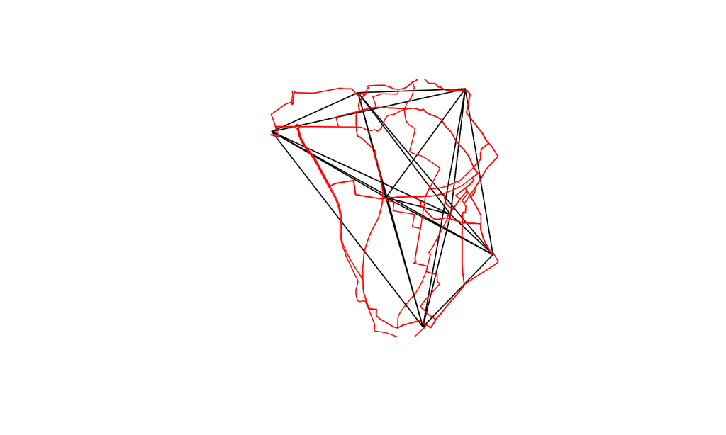

```r
plot(l)
plot(routes_fast, add = T, col = "red")
```

## Future plans

## Routing functions

- Add more services (e.g. OpenTripPlanner)
- Integrate interface
- Add support for OSM data download and analysis
- Via interface to **osmdatar**

## Applications

- Work with practitioners to make it more useful for them (e.g. ITP)
- Link with industry (e.g. ITP)
- Make more international
- A global propensity to cycle tool?
- Better handling of GPS data